```python
import numpy as np
import pandas as pd
from pathlib import Path
%matplotlib inline
```

# Return Forecasting: Read Historical Daily Yen Futures Data

In this notebook, you will load historical Dollar-Yen exchange rate futures data and apply time series analysis and modeling to determine whether there is any predictable behavior.

```python
# Futures contract on the Yen-dollar exchange rate:
# This is the continuous chain of the futures contracts that are 1 month to expiration
yen_futures = pd.read_csv(
    Path("yen.csv"), index_col="Date", infer_datetime_format=True, parse_dates=True
)
yen_futures.head()
```

| Date | Open | High | Low | Last | Change | Settle | Volume | Previous Day Open Interest |
| --- | --- | --- | --- | --- | --- | --- | --- | --- |
| 1976-08-02 | 3398.0 | 3401.0 | 3398.0 | 3401.0 | NaN | 3401.0 | 2.0 | 1.0 |
| 1976-08-03 | 3401.0 | 3401.0 | 3401.0 | 3401.0 | NaN | 3401.0 | 0.0 | 1.0 |
| 1976-08-04 | 3401.0 | 3401.0 | 3401.0 | 3401.0 | NaN | 3401.0 | 0.0 | 1.0 |
| 1976-08-05 | 3401.0 | 3401.0 | 3401.0 | 3401.0 | NaN | 3401.0 | 0.0 | 1.0 |
| 1976-08-06 | 3401.0 | 3401.0 | 3401.0 | 3401.0 | NaN | 3401.0 | 0.0 | 1.0 |

```python
# Trim the dataset to begin on January 1st, 1990
yen_futures = yen_futures.loc["1990-01-01":, :]
yen_futures.head()
```

| Date | Open | High | Low | Last | Change | Settle | Volume | Previous Day Open Interest |
| --- | --- | --- | --- | --- | --- | --- | --- | --- |
| 1990-01-02 | 6954.0 | 6954.0 | 6835.0 | 6847.0 | NaN | 6847.0 | 48336.0 | 51473.0 |
| 1990-01-03 | 6877.0 | 6910.0 | 6865.0 | 6887.0 | NaN | 6887.0 | 38206.0 | 53860.0 |
| 1990-01-04 | 6937.0 | 7030.0 | 6924.0 | 7008.0 | NaN | 7008.0 | 49649.0 | 55699.0 |
| 1990-01-05 | 6952.0 | 6985.0 | 6942.0 | 6950.0 | NaN | 6950.0 | 29944.0 | 53111.0 |
| 1990-01-08 | 6936.0 | 6972.0 | 6936.0 | 6959.0 | NaN | 6959.0 | 19763.0 | 52072.0 |

# Return Forecasting: Initial Time-Series Plotting

Start by plotting the "Settle" price. Do you see any patterns, long-term and/or short?

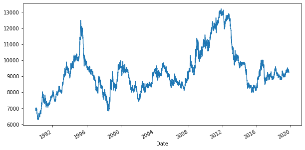

```python
# Plot just the "Settle" column from the dataframe:
yen_futures.Settle.plot(figsize=(10,5))
```

```python
The yen seems to be getting stronger compared to the US dollar.
```

[output not shown]

# Decomposition Using a Hodrick-Prescott Filter

Using a Hodrick-Prescott Filter, decompose the Settle price into a trend and noise.

```python
import statsmodels.api as sm

# Apply the Hodrick-Prescott Filter by decomposing the "Settle" price into two separate series:
yen_futures_noise, yen_futures_trend = sm.tsa.filters.hpfilter(yen_futures["Settle"])
```

```python
# Create a dataframe of just the settle price, and add columns for "noise" and "trend" series from above:
yen_futures_HP = pd.DataFrame()
yen_futures_HP["Settle"] = yen_futures["Settle"]
yen_futures_HP["noise"] = yen_futures_noise
yen_futures_HP["trend"] = yen_futures_trend
yen_futures_HP.head()
```

| Date | Settle | noise | trend |
| --- | --- | --- | --- |
| 1990-01-02 | 6847.0 | -61.503967 | 6908.503967 |
| 1990-01-03 | 6887.0 | -21.799756 | 6908.799756 |
| 1990-01-04 | 7008.0 | 98.942896 | 6909.057104 |
| 1990-01-05 | 6950.0 | 40.776052 | 6909.223948 |
| 1990-01-08 | 6959.0 | 49.689938 | 6909.310062 |

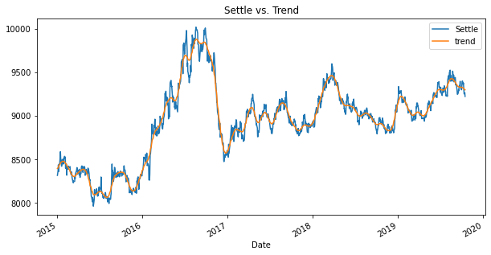

```python
# Plot the Settle Price vs. the Trend for 2015 to the present
yen_futures_PvsT = yen_futures_HP.loc["2015-01-01" :, :]
yen_futures_PvsT = yen_futures_PvsT.drop(columns=["noise"])
yen_futures_PvsT.plot(figsize=(10,5),title= 'Settle vs. Trend')
```

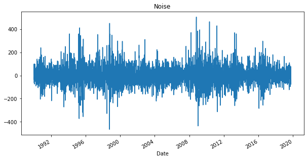

```python
# Plot the Settle Noise
yen_futures_noise.plot(figsize=(10,5), title='Noise')
```

# Forecasting Returns using an ARMA Model

Using futures Settle *Returns*, estimate an ARMA model

1. ARMA: Create an ARMA model and fit it to the returns data. Note: Set the AR and MA ("p" and "q") parameters to p=2 and q=1: order=(2, 1).
2. Output the ARMA summary table and take note of the p-values of the lags. Based on the p-values, is the model a good fit (p < 0.05)?
3. Plot the 5-day forecast of the forecasted returns (the results forecast from ARMA model)

```python
# Create a series using "Settle" price percentage returns, drop any nan"s, and check the results:
# (Make sure to multiply the pct_change() results by 100)
# In this case, you may have to replace inf, -inf values with np.nan"s
returns = (yen_futures[["Settle"]].pct_change() * 100)
returns = returns.replace(-np.inf, np.nan).dropna()
returns.tail()
```

| Date | Settle |
| --- | --- |
| 2019-10-09 | -0.410601 |
| 2019-10-10 | -0.369458 |
| 2019-10-11 | -0.564304 |
| 2019-10-14 | 0.151335 |
| 2019-10-15 | -0.469509 |

```python
import statsmodels.api as sm

# Estimate and ARMA model using statsmodels (use order=(2, 1))
from statsmodels.tsa.arima_model import ARMA
model_arma = ARMA(returns.values, order=(2,1))


# Fit the model and assign it to a variable called results
results_arma = model_arma.fit()
```

```python
# Output model summary results:
results_arma = model_arma.fit()
```

[output not shown]

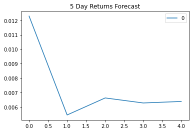

```python
# Plot the 5 Day Returns Forecast
pd.DataFrame(results_arma.forecast(steps=5)[0]).plot(title="5 Day Returns Forecast")
```

# Forecasting the Settle Price using an ARIMA Model

1. Using the *raw* Yen **Settle Price**, estimate an ARIMA model.
   1. Set P=5, D=1, and Q=1 in the model (e.g., ARIMA(df, order=(5,1,1))
   2. P= # of Auto-Regressive Lags, D= # of Differences (this is usually =1), Q= # of Moving Average Lags
2. Output the ARIMA summary table and take note of the p-values of the lags. Based on the p-values, is the model a good fit (p < 0.05)?
3. Construct a 5 day forecast for the Settle Price. What does the model forecast will happen to the Japanese Yen in the near term?

```python
from statsmodels.tsa.arima_model import ARIMA

# Estimate and ARIMA Model:
# Hint: ARIMA(df, order=(p, d, q))
from statsmodels.tsa.arima_model import ARIMA
model_arima = ARIMA(yen_futures['Settle'], order=(5, 1, 1))

# Fit the model
results_arima = model_arima.fit()
```

```python
# Output model summary results:
results_arima.summary()
```

ARIMA Model Results

| Dep. Variable: | D.Settle | No. Observations: | 7514 |
| --- | --- | --- | --- |
| Model: | ARIMA(5, 1, 1) | Log Likelihood | -41944.619 |
| Method: | css-mle | S.D. of innovations | 64.281 |
| Date: | Fri, 26 Nov 2021 | AIC | 83905.238 |
| Time: | 19:35:09 | BIC | 83960.635 |
| Sample: | 1 | HQIC | 83924.259 |

|  | coef | std err | z | P>\|z\| | [0.025 | 0.975] |
| --- | --- | --- | --- | --- | --- | --- |
| const | 0.3161 | 0.700 | 0.452 | 0.652 | -1.056 | 1.688 |
| ar.L1.D.Settle | 0.2828 | 0.699 | 0.405 | 0.686 | -1.086 | 1.652 |
| ar.L2.D.Settle | 0.0007 | 0.016 | 0.043 | 0.965 | -0.030 | 0.032 |
| ar.L3.D.Settle | -0.0126 | 0.012 | -1.031 | 0.302 | -0.037 | 0.011 |
| ar.L4.D.Settle | -0.0136 | 0.015 | -0.889 | 0.374 | -0.044 | 0.016 |
| ar.L5.D.Settle | -0.0011 | 0.018 | -0.064 | 0.949 | -0.036 | 0.034 |
| ma.L1.D.Settle | -0.2978 | 0.698 | -0.426 | 0.670 | -1.667 | 1.071 |

Roots

|  | Real | Imaginary | Modulus | Frequency |
| --- | --- | --- | --- | --- |
| AR.1 | 1.8925 | -1.3779j | 2.3410 | -0.1002 |
| AR.2 | 1.8925 | +1.3779j | 2.3410 | 0.1002 |
| AR.3 | -2.2730 | -3.0189j | 3.7789 | -0.3527 |
| AR.4 | -2.2730 | +3.0189j | 3.7789 | 0.3527 |
| AR.5 | -11.1731 | -0.0000j | 11.1731 | -0.5000 |
| MA.1 | 3.3574 | +0.0000j | 3.3574 | 0.0000 |

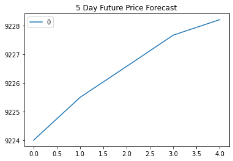

```python
# Plot the 5 Day Price Forecast
pd.DataFrame(results_arima.forecast(steps=5)[0]).plot(title="5 Day Future Price Forecast")
```

# Volatility Forecasting with GARCH

Rather than predicting returns, let's forecast near-term **volatility** of Japanese Yen futures returns. Being able to accurately predict volatility will be extremely useful if we want to trade in derivatives or quantify our maximum loss.

Using futures Settle *Returns*, estimate an GARCH model

1. GARCH: Create an GARCH model and fit it to the returns data. Note: Set the parameters to p=2 and q=1: order=(2, 1).
2. Output the GARCH summary table and take note of the p-values of the lags. Based on the p-values, is the model a good fit (p < 0.05)?
3. Plot the 5-day forecast of the volatility.

```python
from arch import arch_model
```

```python
# Estimate a GARCH model:
model_garch = arch_model(returns, mean="Zero", vol="GARCH", p=2, q=1)


# Fit the model
results_garch = model_garch.fit(disp="on")
```

[output not shown]

```python
# Summarize the model results
results_garch.summary()
```

Zero Mean - GARCH Model Results

| Dep. Variable: | Settle | R-squared: | 0.000 |
| --- | --- | --- | --- |
| Mean Model: | Zero Mean | Adj. R-squared: | 0.000 |
| Vol Model: | GARCH | Log-Likelihood: | -7461.93 |
| Distribution: | Normal | AIC: | 14931.9 |
| Method: | Maximum Likelihood | BIC: | 14959.6 |
|  |  | No. Observations: | 7514 |
| Date: | Fri, Nov 26 2021 | Df Residuals: | 7514 |
| Time: | 19:40:51 | Df Model: | 0 |

Volatility Model

|  | coef | std err | t | P>\|t\| | 95.0% Conf. Int. |
| --- | --- | --- | --- | --- | --- |
| omega | 4.2896e-03 | 2.057e-03 | 2.085 | 3.707e-02 | [2.571e-04,8.322e-03] |
| alpha[1] | 0.0381 | 1.282e-02 | 2.970 | 2.974e-03 | [1.295e-02,6.321e-02] |
| alpha[2] | 0.0000 | 1.703e-02 | 0.000 | 1.000 | [-3.338e-02,3.338e-02] |
| beta[1] | 0.9536 | 1.420e-02 | 67.135 | 0.000 | [ 0.926, 0.981] |

Covariance estimator: robust

```python
# Find the last day of the dataset
last_day = returns.index.max().strftime('%Y-%m-%d')
last_day
```

```
'2019-10-15'
```

```python
# Create a 5 day forecast of volatility
forecast_horizon = 5
# Start the forecast using the last_day calculated above

forecasts = results_garch.forecast(start=last_day, horizon=forecast_horizon)
```

[output not shown]

```python
# Annualize the forecast
intermediate = np.sqrt(forecasts.variance.dropna() * 252)
intermediate.head()
```

| Date | h.1 | h.2 | h.3 | h.4 | h.5 |
| --- | --- | --- | --- | --- | --- |
| 2019-10-15 | 7.434032 | 7.475729 | 7.516851 | 7.55741 | 7.597418 |

```python
# Transpose the forecast so that it is easier to plot
final = intermediate.dropna().T
final.head()
```

| Date | 2019-10-15 |
| --- | --- |
| h.1 | 7.434032 |
| h.2 | 7.475729 |
| h.3 | 7.516851 |
| h.4 | 7.557410 |
| h.5 | 7.597418 |

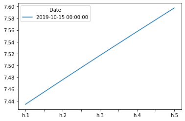

```python
# Plot the final forecast
final.plot()
```

# Conclusions

Based on your time series analysis, would you buy the yen now?

Is the risk of the yen expected to increase or decrease?

Based on the model evaluation, would you feel confident in using these models for trading?